# TzeFungLung_Assign13

jim lung

11-23-2017

# Data 605 Assignment 13

## 1. Use integration by substitution to solve the integral below:

$\int 4e^{-7x}dx$

$u = -7x$

$du = -7dx$

$dx = \frac{du}{-7}$

$\int 4e^{u}\frac{du}{-7}$

$\frac{4}{-7}\int e^udu$

$\frac{4}{-7} e^u + C$

$\frac{4}{-7} e^{-7x} + C$

## 2.

Biologists are treating a pond contaminated with bacteria. The level of contamination is changing at a rate of $\frac{dN}{dt} = - \frac{3150}{t^4}-220$ bacteria per cubic centimeter per day, where t is the number of days since treatment began. Find a function N( t ) to estimate the level of contamination if the level after 1 day was 6530 bacteria per cubic centimeter.

$\frac{dN}{dt} = - \frac{3150}{t^4}-220$

$dN = ( - \frac{3150}{t^4}-220)dt$

$N = \int - \frac{3150}{t^4}-220dt$

$N = \int - \frac{3150}{t^4}dt-\int 220dt$

$N = - \frac{3150}{3t^3} - 220t + C$

$N(1) = - \frac{3150}{3(1)^3} - 220(1) + C = 6530$

$C = 7800$

$N(t) = - \frac{3150}{3(t)^3} - 220(t) + 7800$

$N(0) = - \frac{3150}{3(0)^3} - 220(0) + 7800 = 7800$

$\int_{4.5}^{8.5} 2x-9 dx$

$= [x^2 - 9x]|_{4.5}^{8.5}$

$= (8.5^2-9(8.5)) - (4.5^2-9(4.5))$

$= 16$

## 4. Find the area of the region bounded by the graphs of the given equations

$y = x^2 -2x-2$, $y =x+2$

Graph for equation:

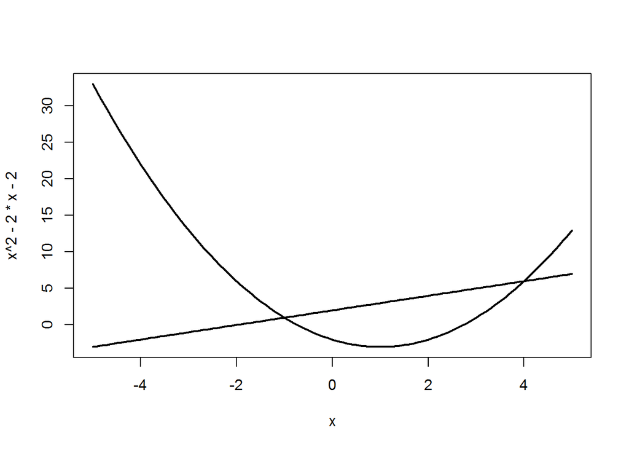

```r
curve(x^2 -2*x-2, lwd = 2, xlim=c(-5, 5))
curve(x+2, lwd = 2, xlim=c(-5, 5), add = TRUE)
```

Intersection point: x^2 -2*x-2 = x+2 x^2 -3*x-4 = 0

```r
f <- function(a){ a^2 - 3*a - 4 }


# zeros of f
root <- polyroot(c(-4, -3, 1))
ifelse(Im(root) == 0, Re(root), root)
```

```
## [1] -1+0i  4-0i
```

Area: $\int_{-1}^{4}x+2 dx -\int_{-1}^{4}x^2 -2x-2 dx$

$=-[\frac{1}{3}x^3 - \frac{3}{2}x^2 -4x]|_{-1}^{4}$

$=20.8333$

## 5. A beauty supply store expects to sell 110 flat irons during the next year. It costs $3.75 to store one flat iron for one year. There is a fixed cost of $8.25 for each order. Find the lot size and the number of orders per year that will minimize inventory costs.

Number of orders per year = n lot size = s Cost = c

ns = 110 s = 110 / n

Assume half of inventory keep in stocks:

$c = 8.25n + \frac{206.25}{n}$

$c' = 8.25 - \frac{206.25}{n^{_{2}}}$

$c'=0$

$0 = 8.25 - \frac{206.25}{n^{_{2}}}$

$n = 5$

Number of order per year is 5

## 6. Use integration by parts to solve the integral below

$\int ln(9x)*x^6dx$

Choose:

$u=ln(9x)$, $\frac{dv}{dx}=x^{6}$

$du = \frac{9}{9x}dx = \frac{1}{x}dx$

$dv = x^6dx$

$v = \frac{1}{7}x^7$

In equation:

$\int u dv= uv-\int v du$

$= ln(9x)\frac{1}{7}x^7 - \int\frac{1}{7}x^7\frac{1}{x}dx$

$==ln(9x)\frac{x^7}{7} - \frac{x^7}{49}-C$

## 7. Determine whether f ( x ) is a probability density function on the interval 1, e^6 . If not, determine the value of the definite integral.

$f(x) = \frac{1}{6x}$

$\int_{1}^{e^6} f(x)dx$

$=\int_{1}^{e^6} \frac{1}{6x}dx$

$=\frac{1}{6} \int_{1}^{e^6} \frac{1}{x}dx$

$= \frac{1}{6} ln(x)|_1^{e^6}$

$=\frac{1}{6} [ln(e^6) - ln(1)]$

$=\frac{1}{6} [6 - 0]$

$=1$